← Geospatial impact estimates

# 11 damage analysis products, one earthquake

3 references, 8 satellite damage products (6 evaluated) · A&A Cell - 11 August 2026

2026-08-11

## What arrived, and where each product looked

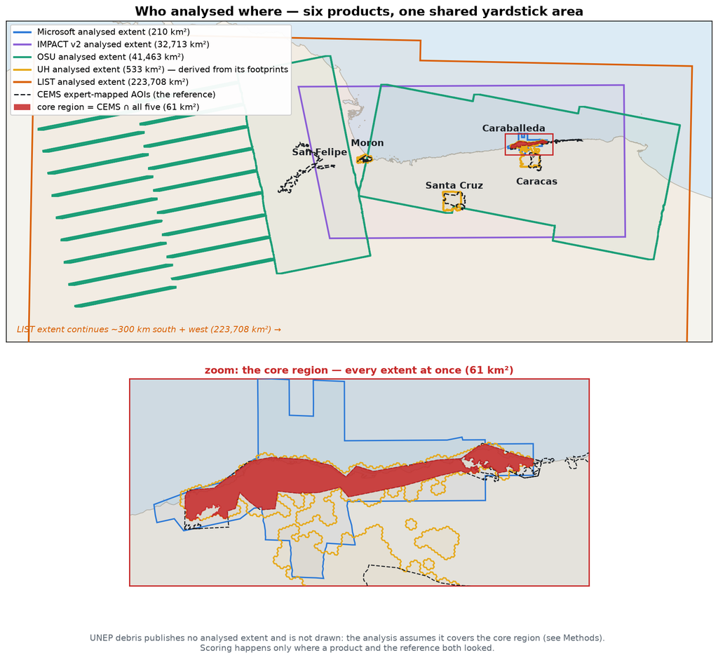

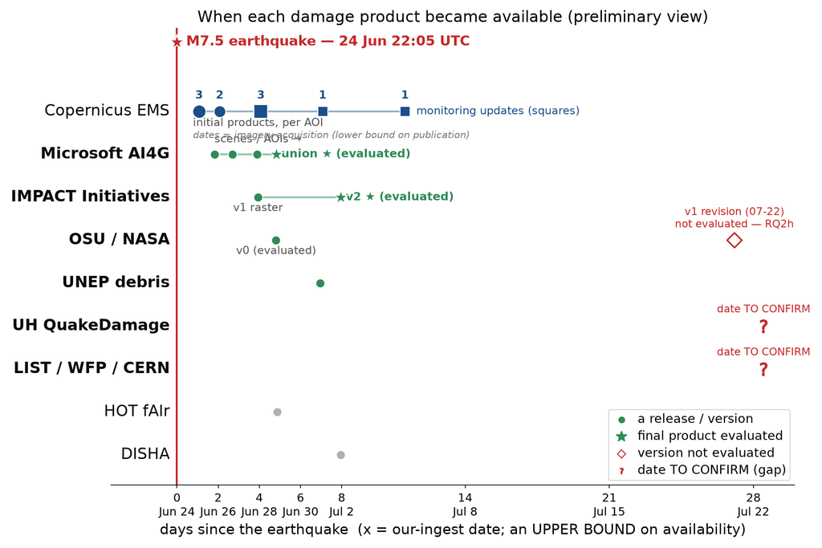

## Three questions

Eight products arrived for the same earthquake within days of each other. A coordinator receiving several of them in the same week has no established way to decide which to trust, for what purpose, or at what spatial scale. So we asked:

- **Can a responder act on a single flagged building?**
- **Do they rank neighbourhoods well enough to prioritise?**
- **What is the sensible way to use them** in the next event?

## Performance metrics by model: building-level analysis

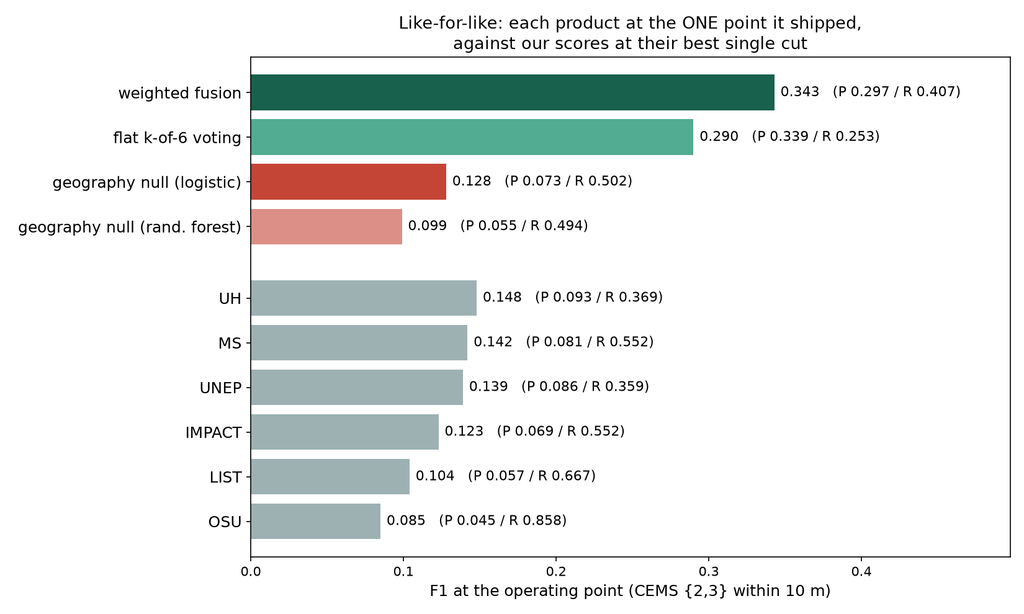

## Precision & recall: single products vs combinations

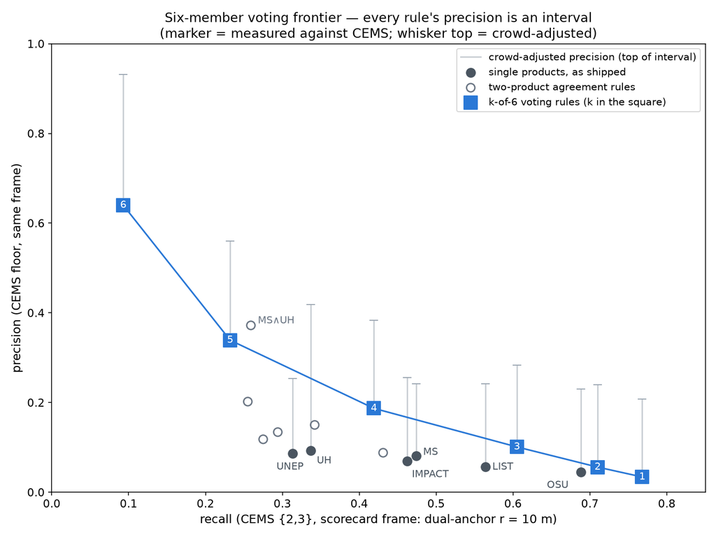

## Can they rank the worst-hit neighbourhoods?

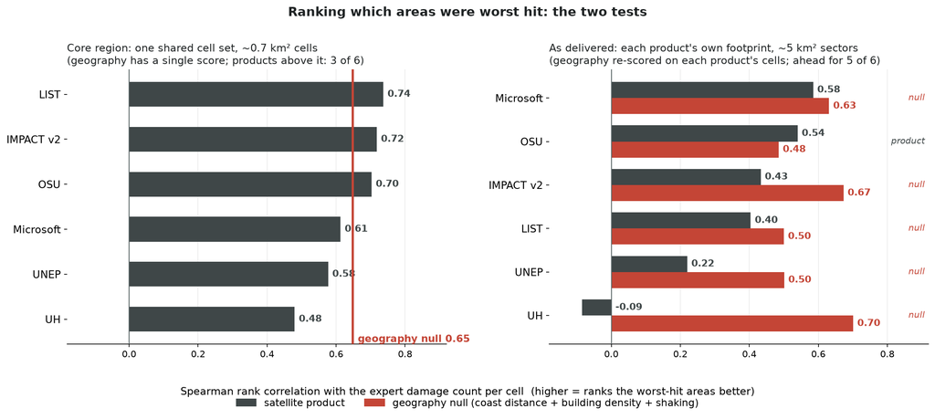

Yes: products can support neighbourhood-level prioritisation. In the core region every product ranks the worst-hit cells far better than chance (ρ 0.48–0.74, n = 133 cells, all p < 10⁻⁸). As delivered the correlations are much lower (−0.09 to 0.58), and UH is statistically indistinguishable from zero.

## Three questions, three answers

1. **Can a responder act on a single flagged building?** **No.** Precision runs 0.05–0.09 even in the damage-dense core region: most flags have nothing wrong underneath them.
2. **Do they rank neighbourhoods well enough to prioritise?** **Yes, with a condition.** Where the damage zone is known and confined (our core region), most products show real prioritisation value (ρ 0.48–0.74); as delivered the signal is much weaker (ρ −0.09 to 0.58).
3. **What is the sensible way to use them in the next event?** **Still open.** The promising lines:
   - **Combine products.** Counting agreement between independent products roughly doubled the accuracy of the best single one here, with no reference data needed.
   - **Match the operating point to the moment.** Different stages of a response may favour precision or coverage differently; field and first-responder feedback should establish where and when higher precision beats broader coverage (open).
   - **Improve the models.** Evaluations like this one show providers where the failures are.

[interactive chart not shown]